# Inferencia estadística III

Inferencia paramétrica: momentos, verosimilitud y método delta

Autor/a

Alejandro Veloz

Este apunte sigue el capítulo 9 de Wasserman. Consideremos ahora modelos paramétricos, $\mathfrak{F} = \{f(x;\theta) : \theta \in \Theta\}$ con $\Theta \subset \mathbb{R}^k$. El problema de inferencia se reduce a estimar $\theta$.

Una pregunta razonable es cómo sabríamos que la distribución que generó los datos pertenece a un modelo paramétrico. Rara vez se sabe, y por eso los métodos no paramétricos son preferibles cuando están disponibles. Aun así, el estudio de los modelos paramétricos es útil por dos razones. En algunos casos el conocimiento previo sugiere que un modelo paramétrico es una aproximación razonable; los conteos de accidentes siguen aproximadamente una Poisson. Y los conceptos de la inferencia paramétrica, en particular la verosimilitud, son la base de buena parte de los métodos de aprendizaje automático de las unidades siguientes.

# 1 Parámetro de interés

Con frecuencia interesa sólo una función $T(\theta)$. Si $X \sim N(\mu, \sigma^2)$ y se quiere estimar $\mu$, entonces $\mu$ es el parámetro de interés y $\sigma$ un parámetro de ruido. El parámetro de interés puede ser una función complicada. Si $X_i$ es el resultado de un examen de sangre y se quiere la fracción de la población con resultado mayor que 1, entonces $\tau = \mathbb{P}(X > 1) = 1 - \Phi((1 - \mu)/\sigma)$. Si $X \sim \text{Gamma}(\alpha, \beta)$ modela un tiempo de vida y se quiere la vida media, $T(\alpha, \beta) = \alpha\beta$.

# 2 Método de los momentos

Es el primer método para construir estimadores paramétricos. No es óptimo pero suele ser fácil de calcular, y sirve como valor inicial para métodos iterativos. Sea $\theta = (\theta_1, \ldots, \theta_k)$. El momento $j$-ésimo es $\alpha_j(\theta) = \mathbb{E}_\theta(X^j)$ y el momento muestral $j$-ésimo es $\hat\alpha_j = n^{-1}\sum_i X_i^j$.

**Definición.** El estimador por el método de los momentos $\hat\theta_n$ es el valor de $\theta$ que resuelve el sistema de $k$ ecuaciones $\alpha_j(\hat\theta_n) = \hat\alpha_j$, $j = 1, \ldots, k$.

Para Bernoulli, $\alpha_1 = p$ y el estimador es $\hat p_n = \bar X_n$. Para la normal, $\alpha_1 = \mu$ y $\alpha_2 = \sigma^2 + \mu^2$, de donde $\hat\mu = \bar X_n$ y $\hat\sigma^2 = n^{-1}\sum_i (X_i - \bar X_n)^2$. Bajo condiciones apropiadas el estimador existe con probabilidad tendiente a uno, es consistente y es asintóticamente normal, con una varianza que se puede escribir en forma cerrada, aunque en la práctica es más fácil obtenerla por bootstrap.

```python
# Gamma(a, b): E(X) = ab, E(X^2) = ab^2 + (ab)^2  ->  a = m1^2/(m2 - m1^2), b = (m2 - m1^2)/m1
x = rng.gamma(3.0, 2.0, 500)
m1, m2 = x.mean(), (x**2).mean()
a_mm, b_mm = m1**2/(m2 - m1**2), (m2 - m1**2)/m1
print("momentos: a = %.3f   b = %.3f   (verdaderos 3 y 2)" % (a_mm, b_mm))
```

```
momentos: a = 3.011   b = 2.021   (verdaderos 3 y 2)
```

# 3 Máxima verosimilitud

Es el método más usado para estimar parámetros en un modelo paramétrico. Sea $X_1, \ldots, X_n$ iid con densidad $f(x;\theta)$.

**Definición.** La **función de verosimilitud** es
$$\mathcal{L}_n(\theta) = \prod_{i=1}^n f(X_i;\theta),$$
y la **log-verosimilitud** es $\ell_n(\theta) = \log \mathcal{L}_n(\theta)$. El **estimador de máxima verosimilitud** (EMV) es el valor $\hat\theta_n$ que maximiza $\mathcal{L}_n(\theta)$.

La verosimilitud es la densidad conjunta de los datos, vista como función del parámetro. No es una densidad en $\theta$; en general no integra uno. Maximizar $\ell_n$ da el mismo resultado que maximizar $\mathcal{L}_n$ y suele ser más cómodo. Multiplicar $\mathcal{L}_n$ por una constante positiva que no dependa de $\theta$ no cambia el EMV, de modo que las constantes se descartan.

**Bernoulli.** $f(x;p) = p^x(1-p)^{1-x}$, luego $\mathcal{L}_n(p) = p^S(1-p)^{n-S}$ con $S = \sum_i X_i$, y $\ell_n(p) = S\log p + (n - S)\log(1-p)$. Derivando e igualando a cero, $\hat p_n = S/n$.

**Normal.** Con $\theta = (\mu, \sigma)$ y descartando constantes, $\ell(\mu, \sigma) = -n\log\sigma - \frac{nS^2}{2\sigma^2} - \frac{n(\bar X - \mu)^2}{2\sigma^2}$, donde $S^2 = n^{-1}\sum_i (X_i - \bar X)^2$. La identidad $\sum_i (X_i - \mu)^2 = nS^2 + n(\bar X - \mu)^2$ se obtiene sumando y restando $\bar X$. Resolviendo las dos ecuaciones de primer orden, $\hat\mu = \bar X$ y $\hat\sigma = S$.

**Un caso que confunde.** $X_1, \ldots, X_n \sim \text{Uniforme}(0, \theta)$. Si $\theta < X_i$ para algún $i$, entonces $f(X_i;\theta) = 0$ y $\mathcal{L}_n(\theta) = 0$. Para $\theta \ge X_{(n)}$, $\mathcal{L}_n(\theta) = \theta^{-n}$, estrictamente decreciente. Luego $\hat\theta_n = X_{(n)}$, el máximo de la muestra. Aquí el EMV no se obtiene derivando, y es el mismo estadístico para el cual falla el bootstrap.

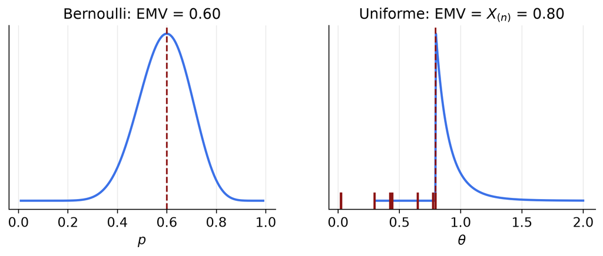

Función de verosimilitud de una Bernoulli con n = 20 y S = 12, y de una uniforme con la muestra marcada en el eje.

```python
S, n = 12, 20
pg = np.linspace(0.01, 0.99, 300)
fig, ax = plt.subplots(1, 2, figsize=(9.5, 3))
ax[0].plot(pg, pg**S * (1-pg)**(n-S), color=MYBLUE, lw=2); ax[0].axvline(S/n, color=MYRED, ls="--")
ax[0].set_xlabel("$p$"); ax[0].set_title("Bernoulli: EMV = %.2f" % (S/n)); ax[0].set_yticks([])
xu = rng.uniform(0, 1, 8); tg = np.linspace(0.3, 2, 400)
L = np.where(tg >= xu.max(), tg**(-8.0), 0)
ax[1].plot(tg, L, color=MYBLUE, lw=2); ax[1].plot(xu, np.zeros(8), "|", color=MYRED, ms=15, mew=2)
ax[1].axvline(xu.max(), color=MYRED, ls="--"); ax[1].set_xlabel("$\\theta$"); ax[1].set_title("Uniforme: EMV = $X_{(n)}$ = %.2f" % xu.max()); ax[1].set_yticks([])
plt.show()
```

En la práctica el EMV se obtiene numéricamente minimizando $-\ell_n(\theta)$. El código siguiente lo hace para la Gamma, cuyo EMV no tiene forma cerrada.

```python
def neg_loglik_gamma(par, x):
    a, b = np.exp(par)                    # parametrización log para mantener a, b > 0
    return -np.sum(stats.gamma.logpdf(x, a, scale=b))

res = optimize.minimize(neg_loglik_gamma, x0=np.log([a_mm, b_mm]), args=(x,), method="BFGS")
a_mv, b_mv = np.exp(res.x)
print("EMV: a = %.3f   b = %.3f   (inicio en el método de los momentos)" % (a_mv, b_mv))
```

```
EMV: a = 2.901   b = 2.098   (inicio en el método de los momentos)
```

# 4 Propiedades del estimador de máxima verosimilitud

Bajo condiciones de regularidad sobre el modelo, que son esencialmente condiciones de suavidad de $f(x;\theta)$ y que se supondrán en adelante, el EMV tiene las siguientes propiedades.

1. Es **consistente**, $\hat\theta_n \xrightarrow{P} \theta_\star$, donde $\theta_\star$ es el valor verdadero.
2. Es **equivariante**: si $\hat\theta_n$ es el EMV de $\theta$, entonces $g(\hat\theta_n)$ es el EMV de $g(\theta)$.
3. Es **asintóticamente normal**, $(\hat\theta_n - \theta_\star)/\widehat{\operatorname{se}} \rightsquigarrow N(0,1)$, y el error estándar suele poder calcularse analíticamente.
4. Es **asintóticamente eficiente**: entre los estimadores razonables, tiene la menor varianza para $n$ grande.
5. Es aproximadamente el estimador bayesiano (apunte V).

En problemas suficientemente complejos estas propiedades dejan de cumplirse y el EMV deja de ser un buen estimador.

## 4.1 Consistencia

La idea de la demostración pasa por la distancia de Kullback y Leibler, $D(f, g) = \int f(x)\log(f(x)/g(x))\,dx$, que satisface $D(f,g) \ge 0$ y $D(f,f) = 0$. El modelo es **identificable** si $\theta \ne \psi$ implica $D(\theta, \psi) > 0$, es decir, parámetros distintos corresponden a distribuciones distintas. Maximizar $\ell_n(\theta)$ equivale a maximizar $M_n(\theta) = n^{-1}\sum_i \log[f(X_i;\theta)/f(X_i;\theta_\star)]$, y por la ley de los grandes números $M_n(\theta) \to -D(\theta_\star, \theta)$, que se maximiza en $\theta_\star$. Para que el maximizador de $M_n$ converja al de $M$ hace falta que la convergencia sea uniforme en $\theta$ y que $D$ esté bien separada de cero fuera de un entorno de $\theta_\star$; con esas dos condiciones, $\hat\theta_n \xrightarrow{P} \theta_\star$.

## 4.2 Equivariancia

Si $\tau = g(\theta)$ con $g$ invertible y $h = g^{-1}$, entonces para todo $\tau$ se tiene $\mathcal{L}(\tau) = \mathcal{L}(h(\tau)) \le \mathcal{L}(\hat\theta) = \mathcal{L}(g(\hat\theta))$. Por ejemplo, si $X_i \sim N(\theta, 1)$ el EMV de $\theta$ es $\bar X_n$ y el EMV de $\tau = e^\theta$ es $e^{\bar X_n}$.

## 4.3 Normalidad asintótica

**Definición.** La **función score** es $s(X;\theta) = \partial \log f(X;\theta)/\partial\theta$. La **información de Fisher** es
$$I_n(\theta) = \mathbb{V}_\theta\Big(\sum_{i=1}^n s(X_i;\theta)\Big) = \sum_{i=1}^n \mathbb{V}_\theta(s(X_i;\theta)).$$
Para $n = 1$ se escribe $I(\theta)$.

Se demuestra que $\mathbb{E}_\theta(s(X;\theta)) = 0$, derivando la identidad $\int f(x;\theta)\,dx = 1$ respecto de $\theta$. De ahí, $\mathbb{V}_\theta(s) = \mathbb{E}_\theta(s^2)$, y además $I_n(\theta) = n I(\theta)$ con
$$I(\theta) = -\mathbb{E}_\theta\Big(\frac{\partial^2 \log f(X;\theta)}{\partial\theta^2}\Big).$$
La información de Fisher mide la curvatura esperada de la log-verosimilitud en $\theta$. Cuanto más curvada, más precisa la estimación.

**Teorema (normalidad asintótica del EMV).** Sea $\operatorname{se} = \sqrt{\mathbb{V}(\hat\theta_n)}$. Bajo condiciones de regularidad, $\operatorname{se} \approx \sqrt{1/I_n(\theta)}$ y
$$\frac{\hat\theta_n - \theta}{\operatorname{se}} \rightsquigarrow N(0,1).$$
Además el resultado sigue valiendo con $\widehat{\operatorname{se}} = \sqrt{1/I_n(\hat\theta_n)}$.

La demostración expande $\ell'(\hat\theta) = 0$ en torno a $\theta$: $0 \approx \ell'(\theta) + (\hat\theta - \theta)\ell''(\theta)$, de donde $\sqrt n(\hat\theta - \theta) \approx [n^{-1/2}\ell'(\theta)] / [-n^{-1}\ell''(\theta)]$. El numerador es una suma de scores centrados y por el teorema central del límite converge a $N(0, I(\theta))$; el denominador converge a $I(\theta)$ por la ley de los grandes números. El cociente converge a $N(0, 1/I(\theta))$.

La consecuencia inmediata es el intervalo $C_n = \hat\theta_n \pm z_{\alpha/2}\,\widehat{\operatorname{se}}$, con $\mathbb{P}_\theta(\theta \in C_n) \to 1 - \alpha$.

**Bernoulli.** $s(X;p) = X/p - (1-X)/(1-p)$, $-s'(X;p) = X/p^2 + (1-X)/(1-p)^2$, luego $I(p) = 1/(p(1-p))$ y $\widehat{\operatorname{se}} = \sqrt{\hat p(1-\hat p)/n}$, el mismo error estándar que en el apunte I.

**Normal con $\sigma$ conocida.** $s(X;\theta) = (X - \theta)/\sigma^2$, $I(\theta) = 1/\sigma^2$, y $\bar X_n \approx N(\theta, \sigma^2/n)$; en este caso la aproximación es exacta.

**Poisson.** $\hat\lambda_n = \bar X_n$, $I(\lambda) = 1/\lambda$, $\widehat{\operatorname{se}} = \sqrt{\hat\lambda_n/n}$, y el intervalo es $\hat\lambda_n \pm z_{\alpha/2}\sqrt{\hat\lambda_n/n}$.

```
se por Fisher = 0.3651   se empírico = 0.3593
```

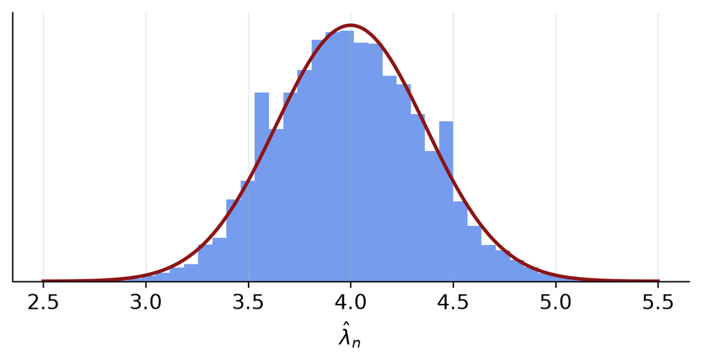

Distribución del EMV de lambda en una Poisson con n = 30 y lambda = 4, sobre diez mil muestras, con la normal predicha por la información de Fisher.

```python
lam, n = 4.0, 30
lh = rng.poisson(lam, (10_000, n)).mean(1)
print("se por Fisher = %.4f   se empírico = %.4f" % (np.sqrt(lam/n), lh.std()))
fig, ax = plt.subplots(figsize=(7, 2.8))
ax.hist(lh, bins=40, density=True, color=MYBLUE, alpha=.7)
g = np.linspace(2.5, 5.5, 300); ax.plot(g, stats.norm.pdf(g, lam, np.sqrt(lam/n)), color=MYRED, lw=2)
ax.set_xlabel("$\\hat\\lambda_n$"); ax.set_yticks([]); plt.show()
```

## 4.4 Optimalidad

Sea $X_i \sim N(\theta, \sigma^2)$. El EMV es $\bar X_n$ y satisface $\sqrt n(\bar X_n - \theta) \rightsquigarrow N(0, \sigma^2)$. La mediana muestral $\tilde\theta_n$ también converge, pero con $\sqrt n(\tilde\theta_n - \theta) \rightsquigarrow N(0, \sigma^2\pi/2)$. Para dos estimadores con varianzas asintóticas $t^2$ y $u^2$ se define la **eficiencia relativa asintótica** $\operatorname{ARE}(U, T) = t^2/u^2$. En el ejemplo, $\operatorname{ARE}(\tilde\theta_n, \hat\theta_n) = 2/\pi \approx 0{,}63$: usar la mediana equivale a usar sólo el 63 % de los datos. En general, si $\hat\theta_n$ es el EMV y $\tilde\theta_n$ otro estimador, $\operatorname{ARE}(\tilde\theta_n, \hat\theta_n) \le 1$. Este resultado supone que el modelo es correcto. Si el modelo es incorrecto, el EMV puede dejar de ser óptimo, y en el ejemplo normal la mediana lo supera en cuanto las colas son más pesadas que las de la normal.

```python
# eficiencia relativa de la mediana frente a la media: normal contra t de Student con 3 gl
for nombre, gen in [("normal", lambda: rng.normal(0, 1, 50)), ("t3", lambda: rng.standard_t(3, 50))]:
    M = np.array([[m.mean(), np.median(m)] for m in (gen() for _ in range(5000))])
    print("%-7s var(media) = %.4f   var(mediana) = %.4f   ARE(mediana, media) = %.2f" % (nombre, M[:, 0].var(), M[:, 1].var(), M[:, 0].var()/M[:, 1].var()))
```

```
normal  var(media) = 0.0203   var(mediana) = 0.0315   ARE(mediana, media) = 0.65
t3      var(media) = 0.0635   var(mediana) = 0.0356   ARE(mediana, media) = 1.78
```

# 5 El método delta

Sea $\tau = g(\theta)$ con $g$ suave. Por equivariancia, el EMV de $\tau$ es $\hat\tau = g(\hat\theta)$. ¿Cuál es su distribución?

**Teorema (método delta).** Si $g$ es diferenciable y $g'(\theta) \ne 0$, entonces
$$\frac{\hat\tau_n - \tau}{\widehat{\operatorname{se}}(\hat\tau_n)} \rightsquigarrow N(0,1), \qquad \widehat{\operatorname{se}}(\hat\tau_n) = |g'(\hat\theta_n)|\,\widehat{\operatorname{se}}(\hat\theta_n).$$

La idea es la expansión $g(\hat\theta) \approx g(\theta) + g'(\theta)(\hat\theta - \theta)$, que es lineal en $\hat\theta$ y por tanto hereda su normalidad con la varianza multiplicada por $g'(\theta)^2$.

**Log-odds.** Con $X_i \sim \text{Bernoulli}(p)$ y $\psi = \log(p/(1-p))$, $g'(p) = 1/(p(1-p))$ y
$$\widehat{\operatorname{se}}(\hat\psi_n) = \frac{1}{p(1-p)}\sqrt{\frac{\hat p(1-\hat p)}{n}}\Big|_{\hat p} = \frac{1}{\sqrt{n\hat p_n(1-\hat p_n)}}.$$

**Logaritmo de la desviación.** Con $X_i \sim N(\mu, \sigma^2)$, $\mu$ conocida y $\psi = \log\sigma$, se calcula $I(\sigma) = 2/\sigma^2$, luego $\widehat{\operatorname{se}}(\hat\sigma) = \hat\sigma/\sqrt{2n}$ y, como $g' = 1/\sigma$, $\widehat{\operatorname{se}}(\hat\psi) = 1/\sqrt{2n}$.

```python
n, p = 200, 0.3
S = rng.binomial(n, p)
phat = S/n
psi = np.log(phat/(1-phat))
se_delta = 1/np.sqrt(n*phat*(1-phat))
psi_b = np.array([(lambda q: np.log(q/(1-q)))(rng.binomial(n, phat)/n) for _ in range(4000)])   # bootstrap paramétrico
print("psi = %.3f   se delta = %.4f   se bootstrap = %.4f" % (psi, se_delta, psi_b.std()))
print("IC 95 %% delta = (%.3f, %.3f)" % (psi - 1.96*se_delta, psi + 1.96*se_delta))
```

```
psi = -0.800   se delta = 0.1529   se bootstrap = 0.1539
IC 95 % delta = (-1.100, -0.500)
```

# 6 Modelos con varios parámetros

Con $\theta = (\theta_1, \ldots, \theta_k)$, sea $H_{jk} = \partial^2\ell_n/\partial\theta_j\partial\theta_k$ la matriz hessiana de la log-verosimilitud. La **matriz de información de Fisher** es $I_n(\theta) = -\mathbb{E}_\theta(H)$ y su inversa es $J_n(\theta) = I_n^{-1}(\theta)$. Bajo regularidad, $\hat\theta - \theta \approx N(0, J_n)$, de modo que $\widehat{\operatorname{se}}_j^2 = J_n(j,j)$ y $\operatorname{Cov}(\hat\theta_j, \hat\theta_k) \approx J_n(j,k)$. El método delta multiparamétrico establece que si $\tau = g(\theta)$ y $\nabla g$ es el gradiente, entonces $\widehat{\operatorname{se}}(\hat\tau) = \sqrt{\hat\nabla g^{\mathsf T}\hat J_n\hat\nabla g}$.

**Coeficiente de variación.** Con $X_i \sim N(\mu, \sigma^2)$ y $\tau = \sigma/\mu$, la información es diagonal, $I_n = \operatorname{diag}(n/\sigma^2, 2n/\sigma^2)$, luego $J_n = \frac1n\operatorname{diag}(\sigma^2, \sigma^2/2)$, y con $\nabla g = (-\sigma/\mu^2, 1/\mu)$ resulta
$$\widehat{\operatorname{se}}(\hat\tau) = \sqrt{\hat\nabla g^{\mathsf T}\hat J_n\hat\nabla g} = \frac{1}{\sqrt n}\sqrt{\frac{\hat\sigma^4}{\hat\mu^4} + \frac{\hat\sigma^2}{2\hat\mu^2}}.$$
El bootstrap paramétrico entrega el mismo número sin cálculo, y el método delta tiene la ventaja de dar una expresión cerrada.

En la práctica, la matriz $J_n$ se obtiene invirtiendo numéricamente el hessiano observado de $-\ell_n$ en $\hat\theta$, que es lo que reportan las rutinas de ajuste de modelos como `statsmodels`.

```python
x = rng.normal(10, 2, 80)
mu, sd = x.mean(), x.std()
tau = sd/mu
se_delta = np.sqrt(sd**4/mu**4 + sd**2/(2*mu**2)) / np.sqrt(len(x))
tau_b = np.array([(lambda v: v.std()/v.mean())(rng.normal(mu, sd, len(x))) for _ in range(4000)])
print("tau = %.4f   se delta = %.4f   se bootstrap paramétrico = %.4f" % (tau, se_delta, tau_b.std()))
```

```
tau = 0.1915   se delta = 0.0157   se bootstrap paramétrico = 0.0156
```

# 7 Cuando el modelo paramétrico es incorrecto

Si se supone un modelo, conviene verificarlo. La verificación informal consiste en mirar los datos, un histograma bimodal cuestiona la normalidad; la formal es un test de bondad de ajuste (apunte IV). El costo de un modelo incorrecto se puede medir con simulación. Si se supone normalidad y se construye el intervalo para la mediana como $\bar X_n \pm z_{\alpha/2}\hat\sigma/\sqrt n$ (válido porque bajo normalidad media y mediana coinciden), pero los datos son asimétricos, la cobertura se desploma. El intervalo bootstrap no paramétrico para la mediana no depende del supuesto.

```python
def cobertura_mediana(gen, mediana_real, n=40, R=1500):
    ok_param, ok_boot = 0, 0
    for _ in range(R):
        xs = gen(n)
        # paramétrico: supone normalidad y estima la mediana por la media
        lo, hi = xs.mean() - 1.96*xs.std()/np.sqrt(n), xs.mean() + 1.96*xs.std()/np.sqrt(n)
        ok_param += lo <= mediana_real <= hi
        # bootstrap de percentiles para la mediana
        mb = np.array([np.median(xs[rng.integers(0, n, n)]) for _ in range(300)])
        lo, hi = np.quantile(mb, [.025, .975])
        ok_boot += lo <= mediana_real <= hi
    return ok_param/R, ok_boot/R

print("normal     (param, boot) = (%.3f, %.3f)" % cobertura_mediana(lambda n: rng.normal(0, 1, n), 0.0))
print("lognormal  (param, boot) = (%.3f, %.3f)" % cobertura_mediana(lambda n: rng.lognormal(0, 1, n), 1.0))
```

```
normal     (param, boot) = (0.932, 0.937)
lognormal  (param, boot) = (0.433, 0.948)
```

# 8 Síntesis esquemática

El método de los momentos iguala momentos poblacionales y muestrales; es sencillo y sirve de punto de partida. El EMV maximiza la verosimilitud, que es la densidad conjunta vista como función del parámetro. Bajo regularidad es consistente, equivariante, asintóticamente normal con $\widehat{\operatorname{se}} = 1/\sqrt{I_n(\hat\theta_n)}$ y asintóticamente eficiente, todo ello si el modelo es correcto. La información de Fisher es la curvatura esperada de la log-verosimilitud. El método delta transporta el error estándar a funciones del parámetro mediante $|g'(\hat\theta)|\,\widehat{\operatorname{se}}(\hat\theta)$, y el bootstrap paramétrico entrega el mismo resultado por simulación. Un modelo incorrecto invalida las garantías, y la forma de protegerse es verificar el modelo o usar métodos no paramétricos.